# A3: SPL Library Checkouts

```
library("dplyr")
library("ggplot2")
source(chart1.R)
source(chart2.R)
source(chart3.R)
source(summary.R)
```

I choose to analyze the checkouts for the different material types. As technology is becoming more accessible I wanted to view the physical versus digital data. Specifically the Audio books, Ebooks and Books as those are the most common types of checkouts. After anaylzing I wanted to figure out if the number of the digital and physical checkouts changed as time went on. As I predicted that in 2017 when the data set started, the physical books would be higher. However as we go to the more recent years, it would decrease and the digital checkouts would increase instead.

### The Dataset

- Who collected/published the data?  
  The data was published and collected by the Seattle Public Library
- What are the parameters of the data (dates, number of checkouts, kinds of books, etc.)? The parameters of this data has usage class (physical or digital), checkout type, materital type, checkout year, checkout month, checkouts, title ISBN, creator, subjects, publishers and publication year.
- How was the data collected or generated?  
  According to the Seattle Public Library website, they collect the data from people who checkout at their libraries.
- Why was the data collected?  
  The data was collected to ensure that the library is continuing to stay up to date with the needs of the community.

-How many observations (rows) are in your data? There are 816354 rows in this dataset.

-How many features (columns) are in the data? There are 12 columns in this dataset.

- What, if any, ethical questions do you need to consider when working with this data? A ethical concern is regarding the privacy of the people checking out the books, and if they are aware that their checkout data is being collected.
- What are possible limitations or problems with this data? (at least 200 words

Possible limitations with this data are that the type of materials available at a given time. The digital copies of items were likely to be less than the number of physical copies, especially before 2020, when many things had to go digital in order to be shared. It would be interesting to see the percentage of physical or digital items that are available to check out as each year passes. The availability would greatly affect the number of checkouts, as there is limited selection. Another area for improvement of this data set is that it only looks at data from the Seattle Public Library, and it would not be able to represent the population fully. The data would allow be able to represent the Seattle area. While it is a larger city/area it still only represents a small portion of the US population. It would be interesting to see how the checkout data changes based on the geographic area of the data. Another limitation is that the titles for the books sometimes include authors illustrators, etc. When filtering out the titles of books it would be difficult to find everything under one title as there may be a small variation in each causing it to filter incorrectly. The titles of the books should just be the title, the illustrator and author should be included in a seperate column.

### First Trends Over Time Chart

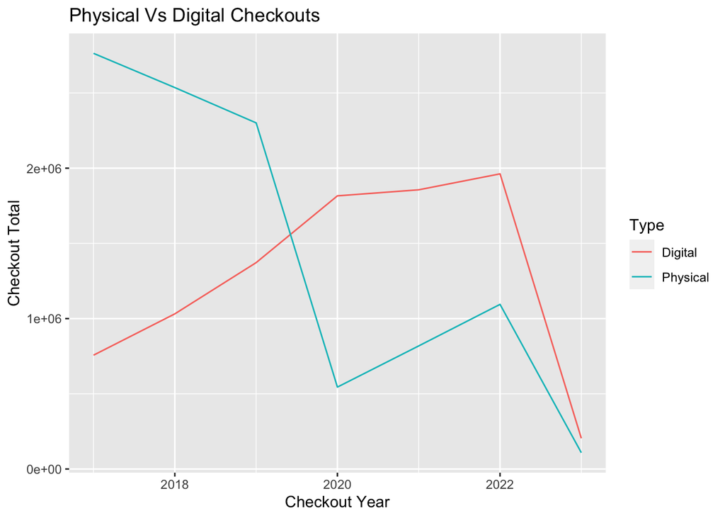

I made this graph because I wanted to the relationship between the physical and digital checkouts and how the amounts would have changed as time went on. There was a large dip in 2020 for physical checkouts, I am predicting due to the pandemic. There was a steady increase on digital downloads from 2017 to 2020. After 2020 it was pretty steady up until 2022. For the physical checkouts after 2020 it was not really picked up since the highest number of checkouts being in 2017. Physical was higher than digital up until mid 2019 where digital had surpassed and has not went below since.

### Second Trends Over Time Chart

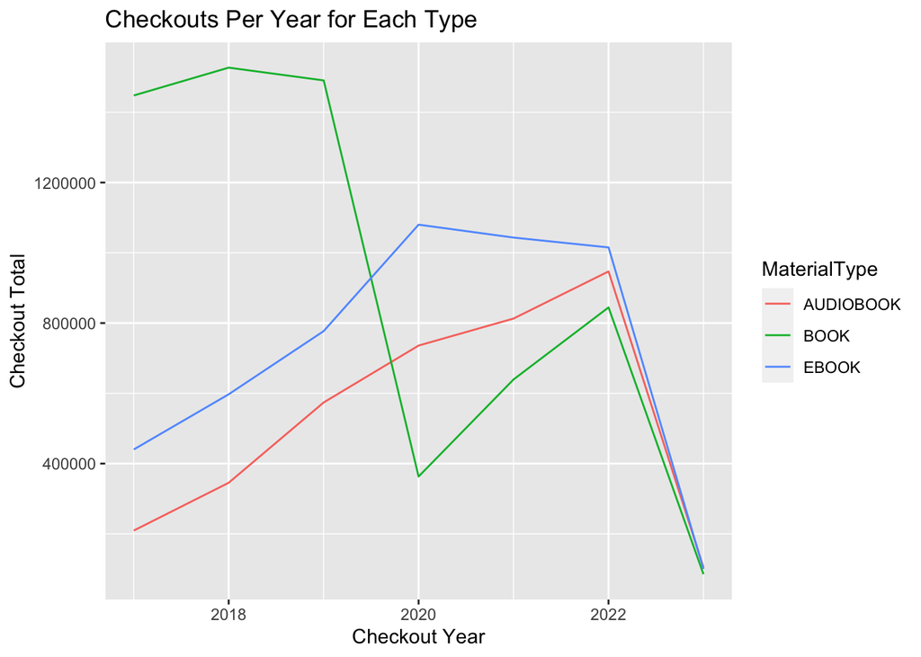

I made this graph to show the relationship between the different Material Types and how as time progressed it affected how many checkouts they had. Books were much higher in 2017 and like the digital/physical graph it dipped in 2020 due to the pandemic. After March 2020 most people were quarantined and unable to go to the library to checkout books like they were able to do previously. For audio books they have had a steady increase since 2017 with no major spikes. For Ebooks the treadline is higher than the audiobook however, the pattern is pretty similar.

### Your Choice

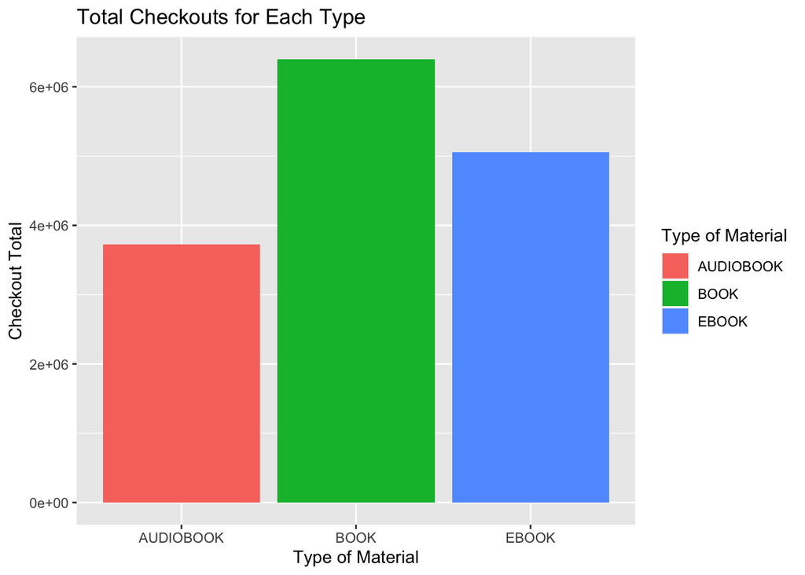